# Worksheet: EDA Worksheet

STT 2860 Intro to Data Mgmt & Visualization

Camden Lauver

Friday, October 02, 2026 @ 09:28 PM

## How We’ll Work Today (Groups + Individual Submission)

- **Use the same groups as Project 1.**
- You are encouraged to **talk, compare code, and help each other debug**, but **each student must submit their own completed worksheet to GitHub** (your own repo).
- If you get stuck, follow this order:
  1. read the error carefully
  2. ask your group
  3. ask me

## GitHub Workflow Reminder (Do This All Class)

**Before you start**

- Pull the most recent version (if needed).
- Open the `.Rmd`, knit once to make sure it runs.

**During work**

- Work in small steps.
- After each checkpoint section: **Knit → Commit → Push**

## Learning Notes (You will write as you go)

Create short notes while you work. You’ll fill these in at the end.

- **One thing I learned today:**
- **One thing that confused me at first but makes sense now:**
  - My NFL barplot was outputting the wrong color despite the color showing correctly in the code, but I realized I placed the color arguement in aes() and not geom_bar().
- **One ggplot trick I want to remember:**

# Packages Used

```r
# load all packages used here
library(tidyverse)
library(nycflights13)
library(skimr)
```

# Datasets Used

## Popular Kids

The dataset `popular.csv` and you can read about it [HERE](https://stat-jet-asu.github.io/Datasets/InstructorDescriptions/popular.html).

```r
# import the dataset from the web URL
kids <- read_csv("https://aokine.github.io/Data/popular.csv")
```

```r
# explore the dataset
glimpse(kids)
```

```
Rows: 478
Columns: 9
$ gender        <chr> "boy", "boy", "girl", "girl", "girl", "girl", "girl", "g…
$ grade         <dbl> 5, 5, 5, 5, 5, 5, 5, 5, 5, 5, 5, 4, 4, 4, 4, 4, 4, 4, 4,…
$ age           <dbl> 11, 10, 11, 11, 10, 11, 10, 10, 10, 10, 11, 10, 9, 9, 9,…
$ district_type <chr> "rural", "rural", "rural", "rural", "rural", "rural", "r…
$ top_goal      <chr> "sports", "popular", "popular", "popular", "popular", "p…
$ grades_rank   <dbl> 1, 2, 4, 2, 4, 4, 3, 3, 3, 4, 2, 2, 2, 4, 4, 1, 3, 3, 2,…
$ sports_rank   <dbl> 2, 1, 3, 3, 2, 2, 4, 4, 2, 3, 3, 3, 3, 2, 3, 3, 1, 4, 3,…
$ looks_rank    <dbl> 4, 4, 1, 4, 1, 1, 1, 2, 1, 2, 1, 4, 4, 3, 2, 2, 2, 1, 1,…
$ money_rank    <dbl> 3, 3, 2, 1, 3, 3, 2, 1, 4, 1, 4, 1, 1, 1, 1, 4, 4, 2, 4,…
```

```r
skim(kids)
```

Data summary

| Name | kids |
| --- | --- |
| Number of rows | 478 |
| Number of columns | 9 |
| _______________________ |  |
| Column type frequency: |  |
| character | 3 |
| numeric | 6 |
| ________________________ |  |
| Group variables | None |

**Variable type: character**

| skim_variable | n_missing | complete_rate | min | max | empty | n_unique | whitespace |
| --- | --- | --- | --- | --- | --- | --- | --- |
| gender | 0 | 1 | 3 | 4 | 0 | 2 | 0 |
| district_type | 0 | 1 | 5 | 8 | 0 | 3 | 0 |
| top_goal | 0 | 1 | 6 | 7 | 0 | 3 | 0 |

**Variable type: numeric**

| skim_variable | n_missing | complete_rate | mean | sd | p0 | p25 | p50 | p75 | p100 | hist |
| --- | --- | --- | --- | --- | --- | --- | --- | --- | --- | --- |
| grade | 0 | 1 | 5.13 | 0.78 | 4 | 5 | 5 | 6 | 6 | ▅▁▇▁▇ |
| age | 0 | 1 | 10.42 | 0.98 | 7 | 10 | 11 | 11 | 13 | ▁▅▆▇▂ |
| grades_rank | 0 | 1 | 2.62 | 1.08 | 1 | 2 | 3 | 4 | 4 | ▆▇▁▇▇ |
| sports_rank | 0 | 1 | 2.09 | 0.98 | 1 | 1 | 2 | 3 | 4 | ▇▇▁▆▂ |
| looks_rank | 0 | 1 | 2.10 | 1.07 | 1 | 1 | 2 | 3 | 4 | ▇▆▁▅▃ |
| money_rank | 0 | 1 | 3.20 | 0.95 | 1 | 3 | 3 | 4 | 4 | ▁▂▁▅▇ |

## Semmelweis Data

The dataset `semmelweisannualbyclinic.csv` and you can read about Dr. Ignaz Semmelweis [HERE](https://www.pbs.org/newshour/health/ignaz-semmelweis-doctor-prescribed-hand-washing). This dataset contains annual observations for two different clinics that led him to implement his handwashing experiment.

```r
semm <- read_csv("https://aokine.github.io/Data/semmelweisannualbyclinic.csv")
```

```r
# explore the dataset
str(semm)
```

```
spc_tbl_ [12 × 4] (S3: spec_tbl_df/tbl_df/tbl/data.frame)
 $ year  : num [1:12] 1841 1842 1843 1844 1845 ...
 $ births: num [1:12] 3036 3287 3060 3157 3492 ...
 $ deaths: num [1:12] 237 518 274 260 241 459 86 202 164 68 ...
 $ clinic: chr [1:12] "clinic 1" "clinic 1" "clinic 1" "clinic 1" ...
 - attr(*, "spec")=
  .. cols(
  ..   year = col_double(),
  ..   births = col_double(),
  ..   deaths = col_double(),
  ..   clinic = col_character()
  .. )
 - attr(*, "problems")=<pointer: 0x557cebc6d540>
```

```r
glimpse(semm)
```

```
Rows: 12
Columns: 4
$ year   <dbl> 1841, 1842, 1843, 1844, 1845, 1846, 1841, 1842, 1843, 1844, 184…
$ births <dbl> 3036, 3287, 3060, 3157, 3492, 4010, 2442, 2659, 2739, 2956, 324…
$ deaths <dbl> 237, 518, 274, 260, 241, 459, 86, 202, 164, 68, 66, 105
$ clinic <chr> "clinic 1", "clinic 1", "clinic 1", "clinic 1", "clinic 1", "cl…
```

```r
skim(semm)
```

Data summary

| Name | semm |
| --- | --- |
| Number of rows | 12 |
| Number of columns | 4 |
| _______________________ |  |
| Column type frequency: |  |
| character | 1 |
| numeric | 3 |
| ________________________ |  |
| Group variables | None |

**Variable type: character**

| skim_variable | n_missing | complete_rate | min | max | empty | n_unique | whitespace |
| --- | --- | --- | --- | --- | --- | --- | --- |
| clinic | 0 | 1 | 8 | 8 | 0 | 2 | 0 |

**Variable type: numeric**

| skim_variable | n_missing | complete_rate | mean | sd | p0 | p25 | p50 | p75 | p100 | hist |
| --- | --- | --- | --- | --- | --- | --- | --- | --- | --- | --- |
| year | 0 | 1 | 1843.50 | 1.78 | 1841 | 1842.00 | 1843.5 | 1845.00 | 1846 | ▇▃▃▃▃ |
| births | 0 | 1 | 3152.75 | 449.08 | 2442 | 2901.75 | 3108.5 | 3338.25 | 4010 | ▇▇▇▂▅ |
| deaths | 0 | 1 | 223.33 | 145.38 | 66 | 100.25 | 219.5 | 263.50 | 518 | ▇▇▃▁▃ |

## Checkpoint 1 (Setup + Datasets)

**Checkpoint task:** Knit your document. If it works, **commit and push** with:

> `worksheet-eda: checkpoint-1 (setup + datasets)`

# NFL Players 2016 Dataset

Description: https://stat-jet-asu.github.io/Datasets/InstructorDescriptions/NFLplayers2016.html

## Load the dataset

```r
NFL <- read_csv("https://aokine.github.io/Data/NFLplayers2016.csv")
```

## Explore the structure with `skim()`

```r
skim(NFL)
```

Data summary

| Name | NFL |
| --- | --- |
| Number of rows | 2764 |
| Number of columns | 12 |
| _______________________ |  |
| Column type frequency: |  |
| character | 7 |
| numeric | 5 |
| ________________________ |  |
| Group variables | None |

**Variable type: character**

| skim_variable | n_missing | complete_rate | min | max | empty | n_unique | whitespace |
| --- | --- | --- | --- | --- | --- | --- | --- |
| Name | 0 | 1 | 7 | 27 | 0 | 2744 | 0 |
| Position | 0 | 1 | 1 | 2 | 0 | 23 | 0 |
| College | 5 | 1 | 3 | 26 | 0 | 322 | 0 |
| Team | 0 | 1 | 5 | 15 | 0 | 32 | 0 |
| PositionGrp | 0 | 1 | 2 | 14 | 0 | 8 | 0 |
| Side | 0 | 1 | 7 | 13 | 0 | 3 | 0 |
| Playtime | 0 | 1 | 6 | 8 | 0 | 5 | 0 |

**Variable type: numeric**

| skim_variable | n_missing | complete_rate | mean | sd | p0 | p25 | p50 | p75 | p100 | hist |
| --- | --- | --- | --- | --- | --- | --- | --- | --- | --- | --- |
| Jersey | 415 | 0.85 | 49.19 | 29.55 | 1 | 23 | 49 | 75 | 99 | ▇▇▆▇▇ |
| Age | 30 | 0.99 | 25.37 | 3.01 | 20 | 23 | 25 | 27 | 43 | ▇▇▂▁▁ |
| Height | 0 | 1.00 | 74.01 | 2.66 | 61 | 72 | 74 | 76 | 81 | ▁▁▆▇▂ |
| Weight | 0 | 1.00 | 244.82 | 46.14 | 150 | 205 | 236 | 288 | 364 | ▂▇▅▅▁ |
| Years | 0 | 1.00 | 3.29 | 3.17 | 0 | 1 | 3 | 5 | 21 | ▇▂▁▁▁ |

# Barplots with `geom_bar()`

For `geom_bar()`, we input an `x` variable and the geometry counts how many of each value occurs in that variable, and that becomes the “y” value for the height of the bars.

## Barplot: Position Groups

Use `x = PositionGrp`.

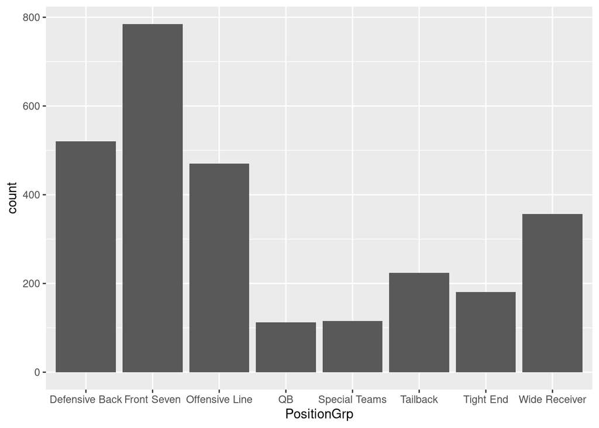

```r
ggplot(NFL, aes(x = PositionGrp)) + geom_bar()
```

### Choose-your-own mini task (pick ONE)

1. Change bar color and outline (`fill =`, `color =`)

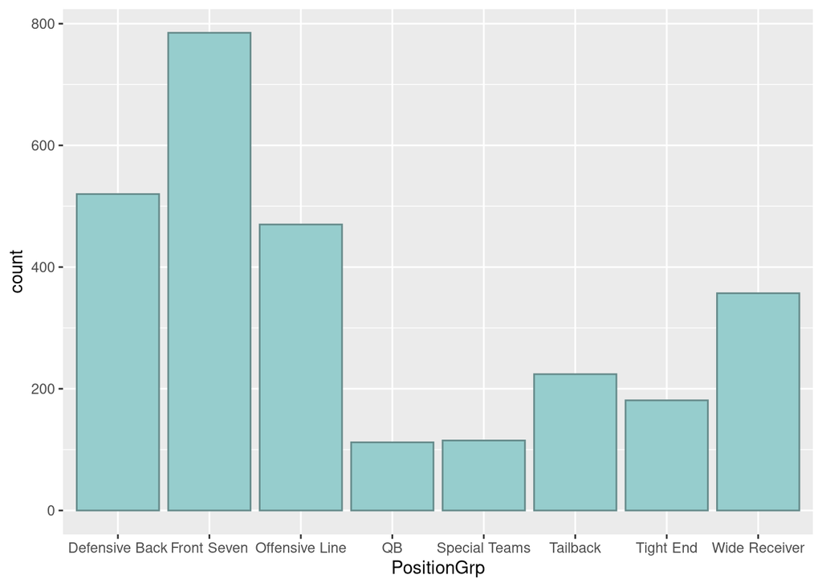

```r
# Do ONE of the three options above. Add your code here.
ggplot(NFL, aes(x = PositionGrp,)) + geom_bar(fill = '#96CDCD', color = 'paleturquoise4')
```

## Fixing category names: Map `PositionGrp` to the y aesthetic

Make `PositionGrp` go on the **y-axis** so labels are easier to read.

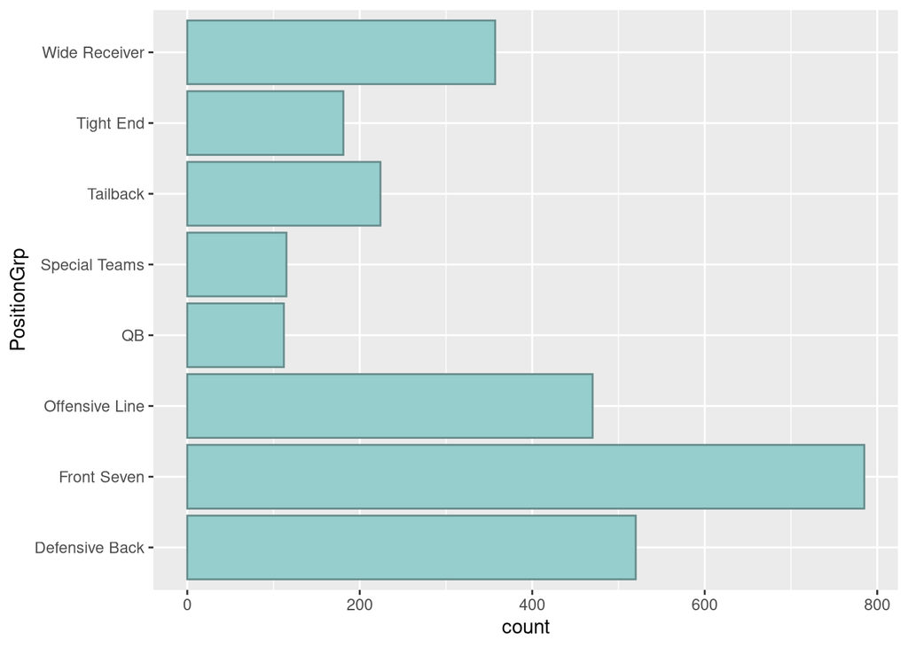

```r
ggplot(NFL, aes(y = PositionGrp,)) + geom_bar(fill = '#96CDCD', color = 'paleturquoise4')
```

## Barplot for Two Variables

Use `PositionGrp` and `Side` as the two variables. Use color/fill to separate groups.

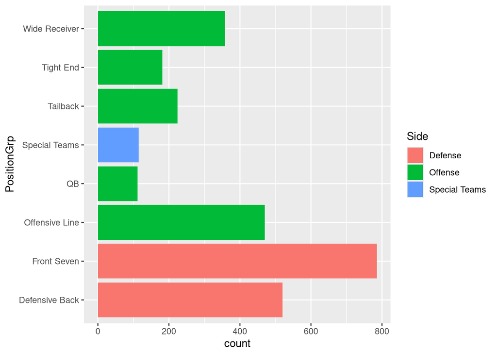

```r
# TODO: Add fill = Side
ggplot(NFL, aes(y = PositionGrp, fill = Side)) + geom_bar()
```

### Quick interpretation (1–2 sentences)

In plain language, what does this plot suggest about how offense/defense/special teams are distributed across position groups?

**Answer:**

- The plot shows us that most position groups are offensive teams. The largest groups are defensive teams though, which are only spread across two groups.

## Checkpoint 2 (Skim + geom_bar)

**Checkpoint task:** Knit your document. If it works, **commit and push** with:

> `worksheet-eda: checkpoint-2 (skim + first barplots)`

# Barplots with `geom_col()`

For `geom_col()`, we input an `x` variable and we input a `y` variable that specifies bar heights. That means we usually **summarize first**.

## Count the Position Groups

```r
# TODO: Create summarized dataset using count()

count(NFL, PositionGrp)
```

```
# A tibble: 8 × 2
  PositionGrp        n
  <chr>          <int>
1 Defensive Back   520
2 Front Seven      785
3 Offensive Line   470
4 QB               112
5 Special Teams    115
6 Tailback         224
7 Tight End        181
8 Wide Receiver    357
```

## Plot counts with `geom_col()`

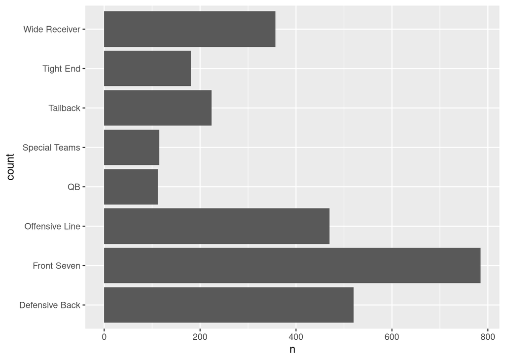

```r
# TODO: Plot using geom_col()

ggplot(count(NFL, PositionGrp), aes(y = PositionGrp, x = n)) + geom_col() + labs(y = "count")
```

## Rearrange the bars in order using `reorder()`

Change the order of the categories according to their counts (largest to smallest).

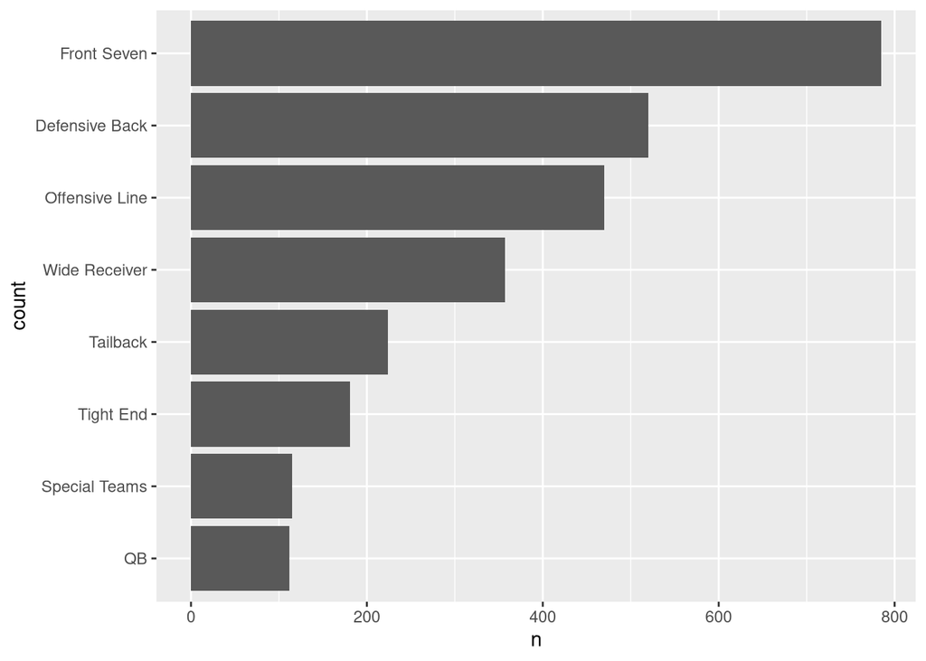

```r
# TODO: Use reorder() to sort bars

ggplot(count(NFL, PositionGrp), aes(y = reorder(PositionGrp, n), x = n)) + geom_col() + labs(y = "count")
```

### Choose-your-own mini task (pick ONE)

1. Add data labels above the bars (hint: `geom_text(aes(label = n), ...)`) **OR**
2. Change to descending order clearly (you might need `-n`) **OR**
3. Show proportions instead of counts (create a `prop = n/sum(n)` column)

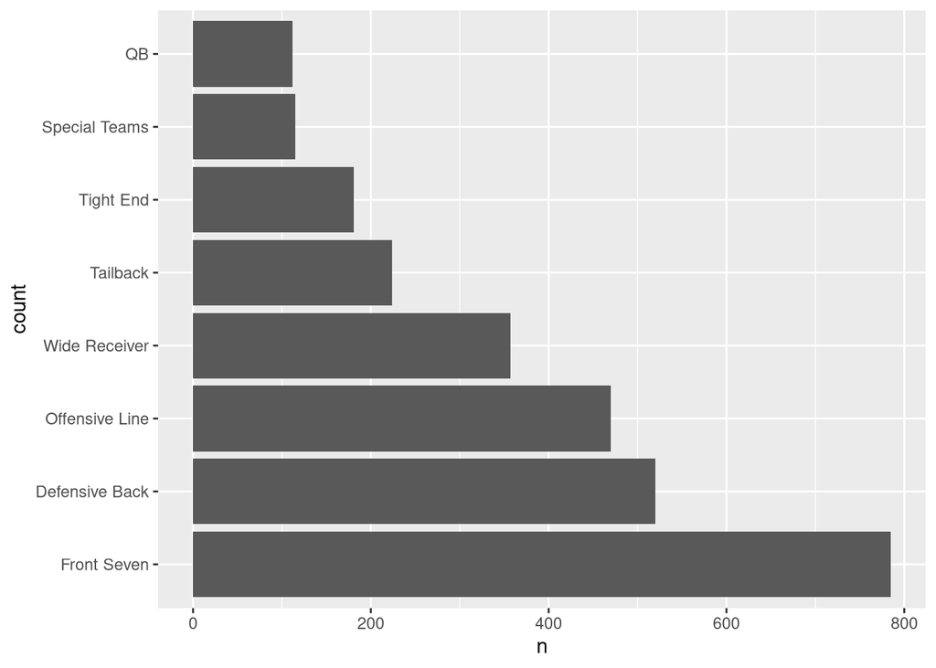

```r
# Do ONE of the three options above. Add your code here.
#2:
ggplot(count(NFL, PositionGrp), aes(y = reorder(PositionGrp, -n), x = n)) + geom_col() + labs(y = "count")
```

## Checkpoint 3 (Two-variable bars + geom_col)

**Checkpoint task:** Knit your document. If it works, **commit and push** with:

> `worksheet-eda: checkpoint-3 (two-variable bars + geom_col)`

# Facets

## Facet Wrap

### Basic Histogram using `Weight`

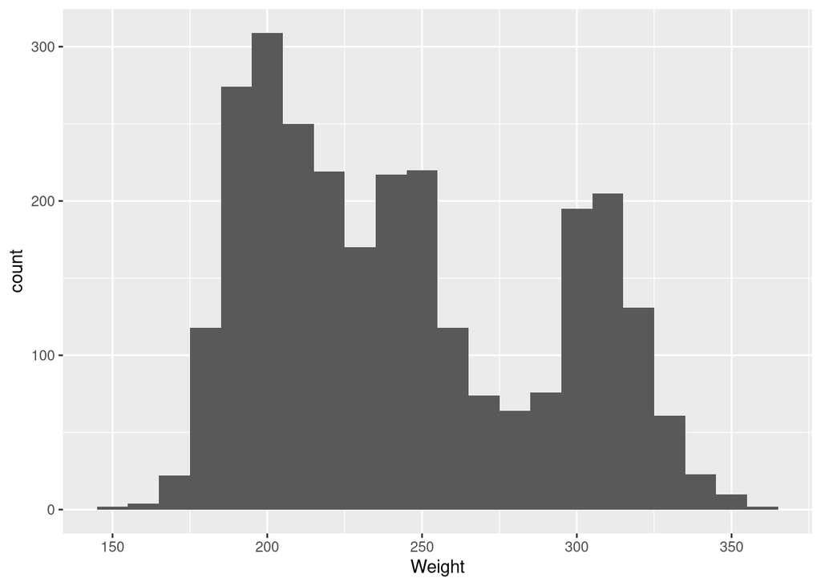

```r
# TODO: Basic histogram
ggplot(NFL, aes(x = Weight)) + geom_histogram(binwidth = 10)
```

### Histogram with Fill using `PositionGrp` OR `Side`

Choose ONE: `fill = PositionGrp` or `fill = Side`

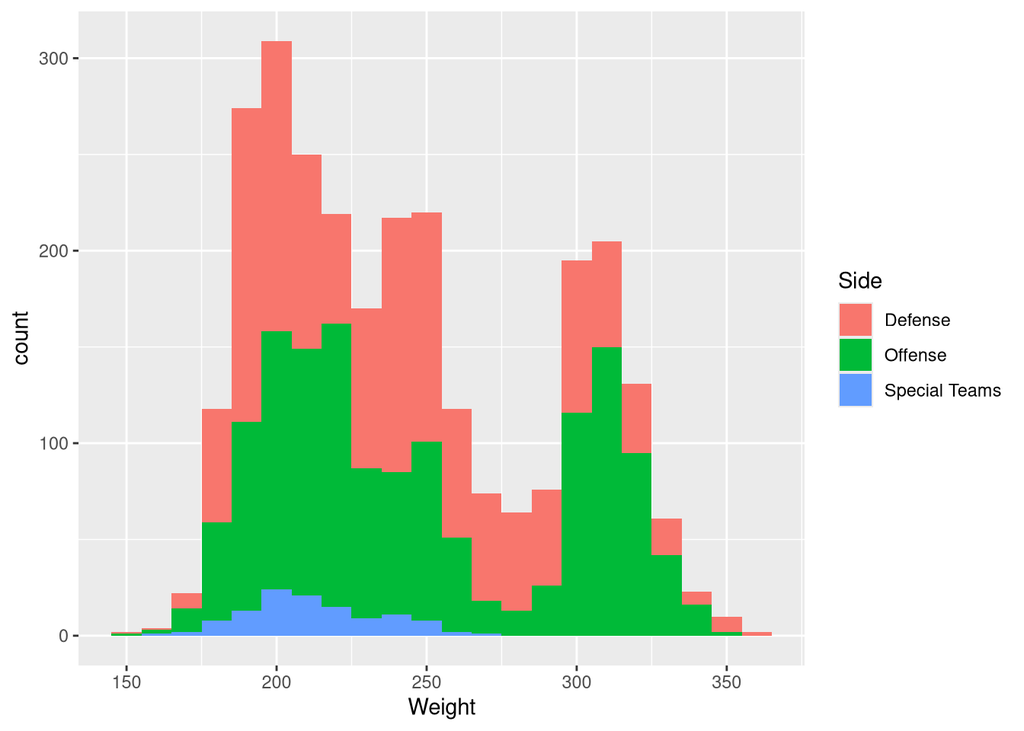

```r
# TODO: Add fill
ggplot(NFL, aes(x = Weight, fill = Side)) + geom_histogram(binwidth = 10)
```

### Histogram using `facet_wrap()` with `PositionGrp`

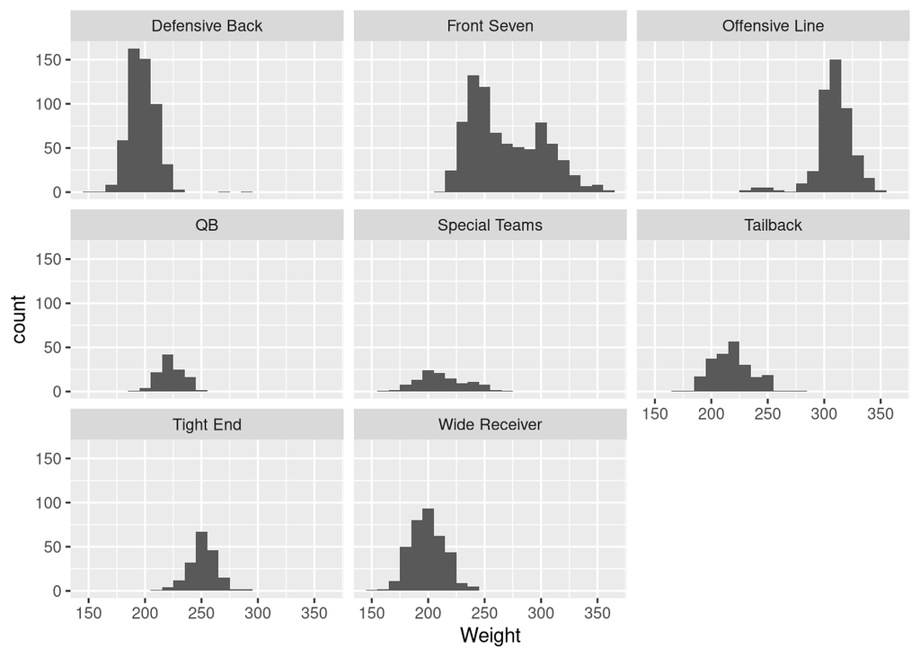

```r
# TODO: facet_wrap by PositionGrp
ggplot(NFL, aes(x = Weight)) + geom_histogram(binwidth = 10) + facet_wrap(~ PositionGrp)
```

### Histogram using `facet_grid()` with `Side`

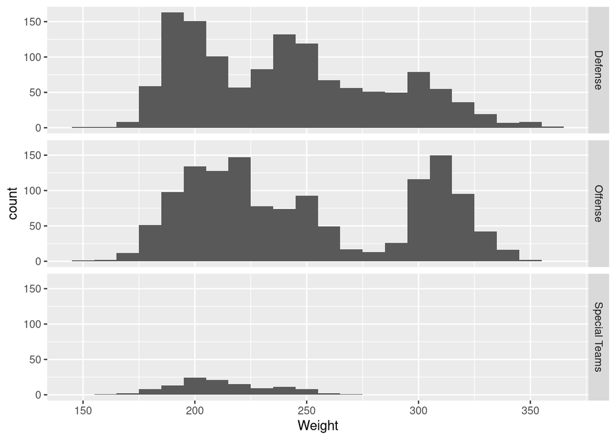

```r
# TODO: facet_grid by Side
ggplot(NFL, aes(x = Weight)) + geom_histogram(binwidth = 10) + facet_grid(Side ~ .)
```

### Quick interpretation (2–3 sentences)

Pick one faceted plot and write what pattern you notice.

**Answer:**

## Checkpoint 4 (Reorder + facets)

**Checkpoint task:** Knit your document. If it works, **commit and push** with:

> `worksheet-eda: checkpoint-4 (reorder + facets)`

# Reflection (Individual)

Fill these in before you submit.

1. **One thing I learned today:**
2. **One thing that confused me at first but makes sense now:**
3. **One ggplot trick I want to remember:**
4. **Choose-your-own reflection (pick ONE):**
- A. One plot I’m proud of and why
- B. One plot I would redesign and how
- C. One dataset question I’d investigate next

## Final Submission

**Final task:** Knit one last time. Then **commit and push** with:

> `worksheet-eda: final (reflection + cleanup)`